# Homework 3

Daniel Oluwafemi Olofin

March 06, 2025

# Question 1

In the examples you saw the built-in function scale(), which accepts a numeric matrix, and centers and scales each column. Specifically, each entry has the mean of its column subtracted, and is then divided by the standard deviation of that column. You may know this as finding a z-score or standardized score. It is often useful to apply the same centering and scaling to a row vector that is not part of the original matrix (such as making a supervised learning prediction when the model is trained on standardized data).

- (a). Create a function named scale_by that accepts a 1 × 𝑝 row vector and an 𝑛 × 𝑝 matrix. From each entry in the vector, it should subtract the mean of the corresponding column mean of the matrix and divide by the corresponding column standard deviation of the matrix. Basically, it’s scaling the vector by the matrix instead of itself.

```r
scale_by <- function(row_vector, matrix_data) {
  # Compute column means and standard deviations of the matrix
  col_means <- colMeans(matrix_data)  # Mean of each column
  col_sds <- apply(matrix_data, 2, sd)  # Standard deviation of each column

  # Scale the row vector using the matrix statistics
  scaled_vector <- (row_vector - col_means) / col_sds

  return(scaled_vector)
}


# Example usage
set.seed(42)
matrix_data <- matrix(rnorm(20), nrow=5, ncol=4)  # 5x4 matrix
row_vector <- c(0.5, -1.2, 0.3, 2.1)  # 1x4 row vector

scaled_vector <- scale_by(row_vector, matrix_data)
print(scaled_vector)
```

```
## [1]  0.08471000 -1.79817668 -0.04030419  1.55117210
```

- 2. Grad student only) Extend the function you wrote in part a) so that it works not only for a row vector, but for every row of a 𝑚 × 𝑝 matrix. Hint: My solution has five lines in the interior of the function, and uses the sweep() function in addition to the previous ones. Here is an example to check your work

```r
scale_by <- function(matrix_to_scale, reference_matrix) {
  # Compute column means and standard deviations of the reference matrix
  col_means <- colMeans(reference_matrix)  # Mean of each column
  col_sds <- apply(reference_matrix, 2, sd)  # Standard deviation of each column

  # Scale the matrix using the reference matrix statistics
  scaled_matrix <- sweep(matrix_to_scale, 2, col_means, "-")  # Subtract column means
  scaled_matrix <- sweep(scaled_matrix, 2, col_sds, "/")  # Divide by column standard deviations

  return(scaled_matrix)
}

# Example usage
set.seed(42)
reference_matrix <- matrix(rnorm(20), nrow=5, ncol=4)  # 5x4 reference matrix
matrix_to_scale <- matrix(rnorm(12), nrow=3, ncol=4)  # 3x4 matrix to scale

scaled_matrix <- scale_by(matrix_to_scale, reference_matrix)
print(scaled_matrix)
```

```
##            [,1]       [,2]        [,3]      [,4]
## [1,] -1.0794284  0.5446907 -0.42682518 0.0250789
## [2,] -3.2076674  1.2049722 -1.47131021 0.6352082
## [3,] -0.8849991 -1.0515300  0.07073904 0.7741092
```

# Question Two

Create an infix function named %count_in% that accepts a numeric vector of length 1 (that is, an ordinary number) as the first argument and a numeric vector of arbitrary length as the second argument. The value it returns should be how many times the first argument appears in the second argument.

```r
`%count_in%` <- function(num, vec) {
  sum(vec == num)  # Count occurrences of num in vec
}

# Example usage
5 %count_in% c(1, 2, 3, 5, 5, 6, 5)  # Returns 3
```

```
## [1] 3
```

```r
7 %count_in% c(1, 2, 3, 4, 5)        # Returns 0
```

```
## [1] 0
```

# Question Three:

Use the command library(help = package) to find a function from one of the standard packages included in R that we haven’t yet covered in this course. Write a paragraph explaining how the function works, and provide an example not included in the documentation.

```r
library(help = stats)
```

`smooth.spline()` is used for smoothing noisy data using a spline-based approach. It fits a smooth curve through a set of noisy observations by minimizing a penalized sum of squares, effectively controlling the trade-off between fitting the data closely and maintaining smoothness. The smoothing is controlled by either degrees of freedom (df) or a smoothing parameter (spar).

Example (Not in Documentation):

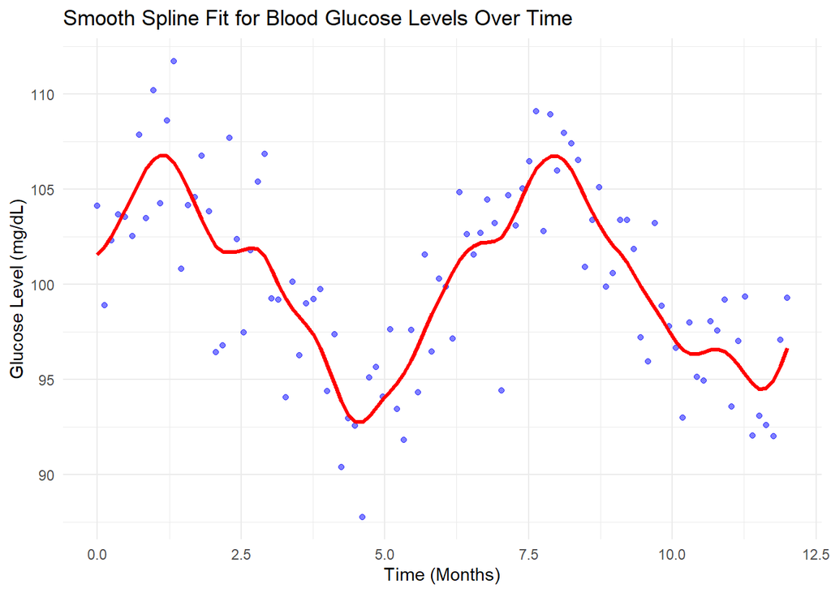

```r
# Load necessary library
library(ggplot2)
# Simulate longitudinal biomarker data (e.g., blood glucose levels)
set.seed(42)
time_points <- seq(0, 12, length.out = 100)  # 12 months of observation
glucose_levels <- 100 + 5 * sin(time_points) + rnorm(100, mean = 0, sd = 3)  # Add noise

# Fit smooth spline
spline_fit <- smooth.spline(time_points, glucose_levels, spar = 0.5)  # Adjust spar for smoothing

# Convert to data frame for visualization
df <- data.frame(Time = time_points, Glucose = glucose_levels,
                 Smoothed_Glucose = predict(spline_fit, time_points)$y)

# Plot original glucose levels and smoothed trend
ggplot(df, aes(x = Time, y = Glucose)) +
  geom_point(color = "blue", alpha = 0.5) +  # Scatter plot of noisy glucose levels
  geom_line(aes(y = Smoothed_Glucose), color = "red", size = 1.2) +  # Smoothed curve
  labs(title = "Smooth Spline Fit for Blood Glucose Levels Over Time",
       x = "Time (Months)", y = "Glucose Level (mg/dL)") +
  theme_minimal()
```

# Question Four:

Now look online for a function in a package not in standard R. Write a paragraph explaining how the function works. Install the package, load with the library() function, and provide an example not included in the documentation.

One useful function from a non-standard R package is `ggplotly()` from the `plotly` package. This function transforms static `ggplot2` visualizations into interactive plots, allowing users to zoom, hover, and click to explore data in more depth. It enhances data visualization by making plots more engaging and informative.

## How ggplotly() Works:

`ggplotly()` takes a ggplot object as input and converts it into an interactive plotly object. This enables interactive features such as tooltips, zooming, and panning without requiring significant changes to the original `ggplot2` code.

```r
# Load necessary libraries
library(ggplot2)
library(plotly)
# Create a static ggplot2 scatter plot
p <- ggplot(mtcars, aes(x = wt, y = mpg, color = factor(cyl))) +
  geom_point(size = 3) +
  labs(title = "Miles Per Gallon vs. Weight",
       x = "Weight (1000 lbs)",
       y = "Miles Per Gallon",
       color = "Cylinders") +
  theme_minimal()

# Convert the static plot to an interactive plot
interactive_plot <- ggplotly(p)

# Display the interactive plot
interactive_plot
```

[interactive chart not shown]